# Library Analysis

### Normalizing Checkouts

So the above analysis is intriguing, but we seem to be ignoring the fact that the number of checkouts a particular book is capable of getting is influenced by the number of copies of that book that are available at a given time.

```r
# Calculating bins
kidsBinsN <- kidsCheckouts %>%
  # Count the number of checkouts per BibNumber
  group_by(BibNumber) %>%
  mutate(count = n(),
          relativeCount = count / maxCopies) %>%
  distinct(BibNumber, .keep_all = TRUE) %>%
  arrange(relativeCount) %>%
  ungroup() %>%
  # Break up data into 100 bins based on checkout number
  mutate(bin = ntile(relativeCount, 100))

# Find average per bin
kidsDistributionN <- kidsBinsN%>%
  group_by(bin) %>%
  summarise(average = round(mean(relativeCount)))
```

And plot the distribution

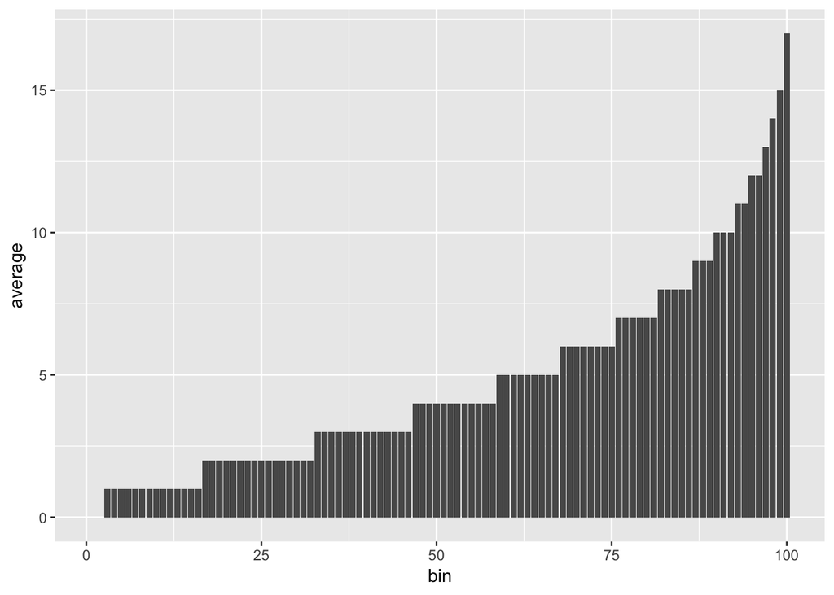

```r
ggplot(kidsDistributionN, aes(x = bin, y = average)) + geom_bar(stat = "identity")
```

```r
# Calculating bins
adultBinsN <- adultCheckouts %>%
  # Count the number of checkouts per BibNumber
  group_by(BibNumber) %>%
  mutate(count = n(),
          relativeCount = count / maxCopies) %>%
  distinct(BibNumber, .keep_all = TRUE) %>%
  arrange(relativeCount) %>%
  ungroup() %>%
  # Break up data into 100 bins based on checkout number
  mutate(bin = ntile(relativeCount, 100))

# Find average per bin
adultDistributionN <- adultBinsN%>%
  group_by(bin) %>%
  summarise(average = round(mean(relativeCount)))
```

And plot the distribution

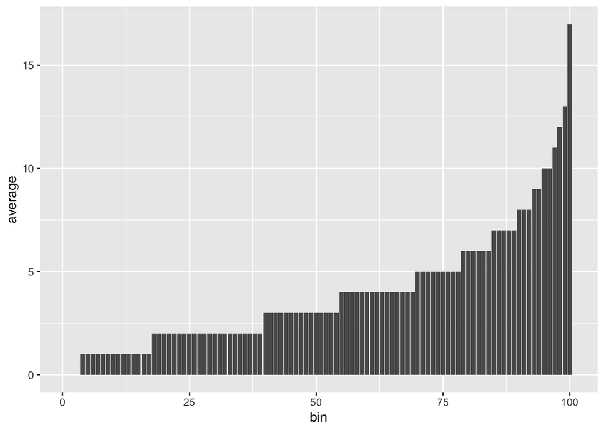

```r
ggplot(adultDistributionN, aes(x = bin, y = average)) + geom_bar(stat = "identity")
```

```r
# Find total number of book checkouts across all books
totalCheckoutsKidsN <- kidsBinsN %>%
  summarise(sum = sum(relativeCount))

# Find total number of checkouts from just the 1% of most checked-out books
one_percent_kidsN <- kidsBinsN %>%
  filter(bin == 100) %>%
  summarise(sum = sum(relativeCount))

round(one_percent_kidsN$sum / totalCheckoutsKidsN$sum * 100)
```

```
## [1] 4
```

```r
# Find total number of book checkouts across all books
totalCheckoutsAdultN <- adultBinsN %>%
  summarise(sum = sum(relativeCount))

# Find total number of checkouts from just the 1% of most checked-out books
one_percent_adultN <- adultBinsN %>%
  filter(bin == 100) %>%
  summarise(sum = sum(relativeCount))

round(one_percent_adultN$sum / totalCheckoutsAdultN$sum * 100)
```

```
## [1] 4
```

What are the most popular books to checkout relative to the maximum number of copies available?

```r
# Calculating bins
kidsMax <- kidsCheckouts %>%
  # Count the number of checkouts per BibNumber
  group_by(BibNumber) %>%
  mutate(count = n(),
          relativeCount = count / maxCopies) %>%
  distinct(BibNumber, .keep_all = TRUE) %>%
  arrange(desc(relativeCount))

kidsMaxAbs <- kidsMax %>%
  arrange(desc(count))
```

These are the top 20 most popular kids’ books, by relative checkouts (i.e. checkouts per copy).

| BibNumber | date | Title | ItemCollection | maxCopies | type | count | relativeCount |
| --- | --- | --- | --- | --- | --- | --- | --- |
| 2500486 | 2017-09-17 | Star wars : clone wars adventures. Volume 9 / [editor, Jeremy Barlow] ; lettering, Michael David Thomas. | nccomic | 1 | kid | 24 | 24 |
| 3215913 | 2017-09-02 | Bad Kitty takes the test / Nick Bruel. | ccef | 18 | kid | 422 | 23.4444444444444 |
| 3279434 | 2017-09-01 | The sisters. 3, Honestly, I love my sister / art and colors, William ; story, Cazenove and William ; [translation by Nanette McGuinness ; lettering by Wilson Ramos, Jr.] | nccomic | 14 | kid | 327 | 23.3571428571429 |
| 3272145 | 2017-09-07 | Time shifters / by Chris Grine. | nccomic | 14 | kid | 327 | 23.3571428571429 |
| 3290438 | 2017-09-03 | Chloe. [#1, The new girl] / story by Greg Tessier ; art by Amandine ; translated by Joe Johnson. | nccomic | 10 | kid | 231 | 23.1 |
| 2137393 | 2017-09-23 | Charmed life / Diana Wynne Jones. | ncfic | 1 | kid | 23 | 23 |
| 3286360 | 2017-11-17 | CatStronauts. [Book 3], Space station situation / by Drew Brockington. | nccomic | 14 | kid | 317 | 22.6428571428571 |
| 3254251 | 2017-09-02 | CatStronauts. [Book 1], Mission Moon / by Drew Brockington. | nccomic | 30 | kid | 679 | 22.6333333333333 |
| 3281068 | 2017-09-03 | Geronimo Stilton. [19], Lost in translation / by Geronimo Stilton ; [script by Leonardo Favia ; translation by Nanette McGuiness ; art by Ryan Jampole ; color by Matt Herms ; lettering by Wilson Ramos… | nccomic | 18 | kid | 405 | 22.5 |
| 3287425 | 2017-09-02 | The girl who thought in pictures : the story of Dr. Temple Grandin / written by Julia Finley Mosca ; illustrated by Daniel Rieley. | ccb | 8 | kid | 179 | 22.375 |

[output cut: 10 more lines]

These are the top 20 most popular kids’ books by absolute number of checkouts:

| BibNumber | date | Title | ItemCollection | maxCopies | type | count | relativeCount |
| --- | --- | --- | --- | --- | --- | --- | --- |
| 136493 | 2017-09-01 | A wrinkle in time / Madeleine L'Engle. | ncfic | 257 | kid | 3258 | 12.6770428015564 |
| 2748046 | 2017-09-02 | Wonder / R.J. Palacio. | ncfic | 290 | kid | 3188 | 10.9931034482759 |
| 3298178 | 2018-01-24 | Dog Man and Cat Kid / written and illustrated by Dav Pilkey as George Beard and Harold Hutchins ; with color by Jose Garibaldi. | nccomic | 164 | kid | 2385 | 14.5426829268293 |
| 3274974 | 2017-09-01 | Dog Man. A tale of two kitties / written and illustrated by Dav Pilkey, as George Beard and Harold Hutchins ; with color by Jose Garibaldi. | nccomic | 141 | kid | 2278 | 16.1560283687943 |
| 3211877 | 2017-09-01 | Dog Man unleashed / written and illustrated by Dav Pilkey, as George Beard and Harold Hutchins, with interior color by Jose Garibaldi. | nccomic | 134 | kid | 2236 | 16.6865671641791 |
| 3193473 | 2017-09-01 | Ghosts / Raina Telgemeier ; with color by Braden Lamb. | nccomic | 110 | kid | 1916 | 17.4181818181818 |
| 3015004 | 2017-09-01 | Sisters / Raina Telgemeier ; with color by Braden Lamb. | nccomic | 113 | kid | 1785 | 15.7964601769912 |
| 2550250 | 2017-09-01 | Are you ready to play outside? / by Mo Willems. | ncrdr | 99 | kid | 1781 | 17.989898989899 |
| 3182291 | 2017-09-01 | Dog Man / written and illustrated by Dav Pilkey, as George Beard and Harold Hutchins ; with color by Jose Garibaldi. | nccomic | 111 | kid | 1739 | 15.6666666666667 |
| 3298874 | 2017-11-18 | The getaway / by Jeff Kinney. | ncfic | 108 | kid | 1642 | 15.2037037037037 |

[output cut: 10 more lines]

```r
# Calculating bins
adultMax <- adultCheckouts %>%
  # Count the number of checkouts per BibNumber
  group_by(BibNumber) %>%
  mutate(count = n(),
          relativeCount = count / maxCopies) %>%
  distinct(BibNumber, .keep_all = TRUE) %>%
  arrange(desc(relativeCount))

adultMaxAbs <- adultMax %>%
  arrange(desc(count))
```

These are the top 20 most popular adult books, by relative checkouts (i.e., checkouts per copy).

| BibNumber | date | Title | ItemCollection | maxCopies | type | count | relativeCount |
| --- | --- | --- | --- | --- | --- | --- | --- |
| 3298225 | 2017-10-05 | Aging : an apprenticeship / Nan Narboe, editor. | canew | 4 | adult | 93 | 23.25 |
| 2548021 | 2017-09-16 | Scrooged [videorecording] / Paramount Pictures Corporation in association with Mirage Productions ; produced by Richard Donner and Art Linson ; directed by Richard Donner ; written by Mitch Glazer &am… | nahol | 1 | adult | 23 | 23 |
| 3269859 | 2017-09-05 | Real life organizing : clean and clutter-free in 15 minutes a day / Cassandra Aarssen ; foreword by Peter Walsh. | canew | 6 | adult | 136 | 22.6666666666667 |
| 3274859 | 2017-09-09 | The cooking gene : a journey through African American culinary history in the Old South / Michael W. Twitty. | canew | 13 | adult | 274 | 21.0769230769231 |
| 3165436 | 2017-09-03 | Just one damned thing after another / Jodi Taylor. | canew | 5 | adult | 103 | 20.6 |
| 3295695 | 2017-09-01 | The heart's invisible furies / John Boyne. | canew | 15 | adult | 308 | 20.5333333333333 |
| 3270693 | 2017-10-02 | The power of eight : harnessing the miraculous energies of a small group to heal others, your life, and the world / Lynne McTaggart. | canew | 4 | adult | 82 | 20.5 |
| 3290343 | 2017-09-02 | Macramé : the craft of creative knotting for your home / Fanny Zedenius ; photography by Kim Lightbody. | nanew | 6 | adult | 122 | 20.3333333333333 |
| 3271859 | 2017-09-03 | The Scandinavian home : interiors inspired by light / Niki Brantmark. | canew | 5 | adult | 100 | 20 |
| 3165868 | 2017-09-08 | Downsizing the family home : what to save, what to let go / Marni Jameson ; foreword by Mark Brunetz. | canew | 5 | adult | 100 | 20 |

[output cut: 10 more lines]

These are the top 20 most popular adult books by absolute number of checkouts:

| BibNumber | date | Title | ItemCollection | maxCopies | type | count | relativeCount |
| --- | --- | --- | --- | --- | --- | --- | --- |
| 3254959 | 2017-09-01 | Less : a novel / Andrew Sean Greer. | canew | 264 | adult | 5265 | 19.9431818181818 |
| 3368387 | 2018-10-09 | The witch elm / Tana French. | canew | 357 | adult | 3300 | 9.2436974789916 |
| 3305470 | 2017-09-30 | Origin : a novel / Dan Brown. | canew | 311 | adult | 2866 | 9.21543408360129 |
| 3279309 | 2017-11-14 | Future home of the living god : a novel / Louise Erdrich. | canew | 276 | adult | 2415 | 8.75 |
| 3271995 | 2017-09-16 | The ninth hour / Alice McDermott. | canew | 270 | adult | 2283 | 8.45555555555556 |
| 3208794 | 2017-09-01 | Lincoln in the bardo : a novel / George Saunders. | nanew | 112 | adult | 1232 | 11 |
| 3378739 | 2018-11-02 | The white darkness / David Grann. | nanew | 226 | adult | 1146 | 5.07079646017699 |
| 3229245 | 2017-09-01 | The leavers : a novel / Lisa Ko. | canew | 47 | adult | 768 | 16.3404255319149 |
| 3215398 | 2017-09-02 | Autumn / Ali Smith. | nanew | 53 | adult | 713 | 13.4528301886792 |
| 3344829 | 2018-02-15 | Asymmetry / Lisa Halliday. | canew | 53 | adult | 704 | 13.2830188679245 |

[output cut: 10 more lines]